# Species-area curves and vegetation-formation similarity

Gianfranco Villamonte Cuneo

2026-06-02

# 1 Objective

This workflow demonstrates two biodiversity-monitoring analyses commonly used to evaluate flora survey data:

1. **Species-area / species-accumulation curves**, used to assess how observed species richness increases with the number of evaluated sampling units.
2. **Community similarity analysis**, used to compare vegetation formations based on species composition and relative cover.

The original workflow was developed for applied environmental monitoring datasets. This public version uses a synthetic anonymized dataset that preserves the analytical structure while removing project-specific names, locations, and original observations.

# 2 Packages

```r
options(repos = c(CRAN = "https://cloud.r-project.org"))

packages <- c(
  "readr", "dplyr", "tidyr", "purrr", "stringr",
  "ggplot2", "viridis", "vegan", "tibble", "ggdendro"
)

missing_packages <- setdiff(packages, rownames(installed.packages()))
if (length(missing_packages) > 0) {
  install.packages(missing_packages)
}

invisible(lapply(packages, library, character.only = TRUE))

theme_set(theme_bw())
```

# 3 Data

The example dataset is structured in long format. Each row represents the relative cover of one species in one sampling unit.

```r
data_file <- "data/flora_community_monitoring_example.csv"

flora <- readr::read_csv(data_file, show_col_types = FALSE) %>%
  mutate(
    survey_year = as.integer(survey_year),
    season = factor(season, levels = c("Wet season", "Dry season", "Winter")),
    zone = factor(zone),
    vegetation_formation = factor(vegetation_formation),
    station_id = factor(station_id),
    sampling_unit = factor(sampling_unit),
    species = factor(species),
    relative_cover = as.numeric(relative_cover)
  )

dplyr::glimpse(flora)
```

```
## Rows: 4,321
## Columns: 8
## $ survey_year          <int> 2018, 2018, 2018, 2018, 2018, 2018, 2018, 2018, 2…
## $ season               <fct> Wet season, Wet season, Wet season, Wet season, W…
## $ zone                 <fct> Zone A, Zone A, Zone A, Zone A, Zone A, Zone A, Z…
## $ vegetation_formation <fct> Shrubland, Shrubland, Shrubland, Shrubland, Shrub…
## $ station_id           <fct> ST_001, ST_001, ST_001, ST_001, ST_001, ST_001, S…
## $ sampling_unit        <fct> ST_001_2018, ST_001_2018, ST_001_2018, ST_001_201…
## $ species              <fct> Species A, Species D, Species C, Species M, Speci…
## $ relative_cover       <dbl> 4.054, 8.113, 1.342, 1.003, 4.720, 3.894, 4.133, …
```

## 3.1 Dataset summary

```r
flora %>%
  summarise(
    records = n(),
    zones = n_distinct(zone),
    vegetation_formations = n_distinct(vegetation_formation),
    seasons = n_distinct(season),
    sampling_units = n_distinct(sampling_unit),
    species = n_distinct(species)
  )
```

```
## # A tibble: 1 × 6
##   records zones vegetation_formations seasons sampling_units species
##     <int> <int>                 <int>   <int>          <int>   <int>
## 1    4321     3                     4       3            144      24
```

```r
flora %>%
  count(zone, vegetation_formation, season, name = "records") %>%
  arrange(zone, vegetation_formation, season)
```

```
## # A tibble: 36 × 4
##    zone   vegetation_formation season     records
##    <fct>  <fct>                <fct>        <int>
##  1 Zone A Cactus scrub         Wet season     119
##  2 Zone A Cactus scrub         Dry season     129
##  3 Zone A Cactus scrub         Winter         130
##  4 Zone A Desert scrub         Wet season     118
##  5 Zone A Desert scrub         Dry season     119
##  6 Zone A Desert scrub         Winter         112
##  7 Zone A Riparian vegetation  Wet season     129
##  8 Zone A Riparian vegetation  Dry season     121
##  9 Zone A Riparian vegetation  Winter         117
## 10 Zone A Shrubland            Wet season     115
## # ℹ 26 more rows
```

# 4 Helper functions

```r
make_community_matrix <- function(data, unit_col = sampling_unit, species_col = species, value_col = relative_cover) {
  data %>%
    group_by({{ unit_col }}, {{ species_col }}) %>%
    summarise(value = sum({{ value_col }}, na.rm = TRUE), .groups = "drop") %>%
    tidyr::pivot_wider(
      names_from = {{ species_col }},
      values_from = value,
      values_fill = 0
    ) %>%
    arrange({{ unit_col }}) %>%
    tibble::column_to_rownames(var = rlang::as_name(rlang::ensym(unit_col))) %>%
    as.data.frame()
}

safe_file_name <- function(x) {
  x %>%
    stringr::str_replace_all("[^A-Za-z0-9]+", "_") %>%
    stringr::str_replace_all("_+", "_") %>%
    stringr::str_replace_all("^_|_$", "")
}
```

# 5 Species-accumulation curves

Species-accumulation curves were calculated for each combination of zone, vegetation formation, and season. The curve estimates the cumulative number of species detected as sampling units are added.

The workflow also estimates Chao-2 richness using `vegan::specpool()`, which provides a non-parametric estimate of total species richness based on incidence patterns across sampling units.

```r
curve_groups <- flora %>%
  distinct(zone, vegetation_formation, season) %>%
  arrange(zone, vegetation_formation, season)

species_area_results <- list()
curve_plots <- list()

for (i in seq_len(nrow(curve_groups))) {
  current_group <- curve_groups[i, ]

  group_data <- flora %>%
    filter(
      zone == current_group$zone,
      vegetation_formation == current_group$vegetation_formation,
      season == current_group$season
    )

  community_matrix <- make_community_matrix(group_data)

  if (nrow(community_matrix) < 2 || ncol(community_matrix) < 2) {
    next
  }

  accumulation <- vegan::specaccum(community_matrix, method = "exact")
  estimators <- vegan::specpool(community_matrix)

  accumulation_df <- tibble(
    sampling_units = accumulation$sites,
    richness = accumulation$richness,
    sd = accumulation$sd
  )

  observed_richness <- tail(accumulation$richness, 1)
  chao2 <- estimators$chao
  r_squared <- summary(lm(richness ~ sampling_units, data = accumulation_df))$r.squared

  plot_title <- paste(
    current_group$zone,
    current_group$vegetation_formation,
    current_group$season,
    sep = " | "
  )

  curve_plot <- ggplot(accumulation_df, aes(x = sampling_units, y = richness)) +
    geom_ribbon(aes(ymin = richness - 2 * sd, ymax = richness + 2 * sd), alpha = 0.20) +
    geom_line(linewidth = 1) +
    geom_hline(yintercept = chao2, linetype = "dashed") +
    annotate(
      "text",
      x = max(accumulation_df$sampling_units) * 0.80,
      y = observed_richness * 0.95,
      label = paste0("S(obs) = ", round(observed_richness, 1))
    ) +
    annotate(
      "text",
      x = max(accumulation_df$sampling_units) * 0.80,
      y = chao2 * 1.03,
      label = paste0("Chao-2 = ", round(chao2, 1))
    ) +
    annotate(
      "text",
      x = max(accumulation_df$sampling_units) * 0.80,
      y = min(accumulation_df$richness),
      label = paste0("R² = ", round(r_squared, 3))
    ) +
    labs(
      title = plot_title,
      x = "Sampling units evaluated",
      y = "Cumulative species richness"
    ) +
    theme(
      plot.title = element_text(face = "bold"),
      axis.title = element_text(face = "bold")
    )

  curve_plots[[i]] <- curve_plot

  output_name <- paste0(
    "outputs/species_area_curves/species_area_",
    safe_file_name(plot_title),
    ".png"
  )

  ggsave(output_name, curve_plot, width = 9, height = 5.5, dpi = 300)

  species_area_results[[i]] <- tibble(
    zone = as.character(current_group$zone),
    vegetation_formation = as.character(current_group$vegetation_formation),
    season = as.character(current_group$season),
    sampling_units = nrow(community_matrix),
    species_columns = ncol(community_matrix),
    observed_richness = observed_richness,
    chao2 = chao2,
    r_squared = r_squared
  )
}

species_area_summary <- bind_rows(species_area_results) %>%
  arrange(zone, vegetation_formation, season)

readr::write_csv(species_area_summary, "outputs/tables/species_area_summary.csv")

species_area_summary
```

```
## # A tibble: 36 × 8
##    zone   vegetation_formation season     sampling_units species_columns
##    <chr>  <chr>                <chr>               <int>           <int>
##  1 Zone A Cactus scrub         Dry season             12              23
##  2 Zone A Cactus scrub         Wet season             12              24
##  3 Zone A Cactus scrub         Winter                 12              23
##  4 Zone A Desert scrub         Dry season             12              24
##  5 Zone A Desert scrub         Wet season             12              23
##  6 Zone A Desert scrub         Winter                 12              21
##  7 Zone A Riparian vegetation  Dry season             12              24
##  8 Zone A Riparian vegetation  Wet season             12              23
##  9 Zone A Riparian vegetation  Winter                 12              24
## 10 Zone A Shrubland            Dry season             12              24
## # ℹ 26 more rows
## # ℹ 3 more variables: observed_richness <dbl>, chao2 <dbl>, r_squared <dbl>
```

## 5.1 Example species-accumulation curve

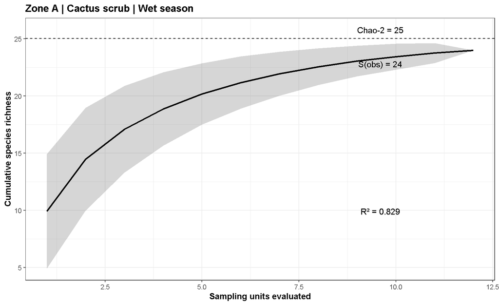

```r
curve_plots[[which(!purrr::map_lgl(curve_plots, is.null))[1]]]
```

# 6 Community similarity analysis

Community similarity was calculated between vegetation formations within each zone and season. The workflow aggregates relative cover by vegetation formation and species, then computes Jaccard dissimilarity using `vegan::vegdist()`.

The dendrograms use average-linkage hierarchical clustering. For visualization, the y-axis is shown as similarity, where higher values indicate more similar species composition among vegetation formations.

```r
similarity_groups <- flora %>%
  distinct(zone, season) %>%
  arrange(zone, season)

similarity_results <- list()
dendrogram_plots <- list()

for (i in seq_len(nrow(similarity_groups))) {
  current_group <- similarity_groups[i, ]

  group_data <- flora %>%
    filter(zone == current_group$zone, season == current_group$season) %>%
    group_by(vegetation_formation, species) %>%
    summarise(relative_cover = sum(relative_cover, na.rm = TRUE), .groups = "drop") %>%
    tidyr::pivot_wider(
      names_from = species,
      values_from = relative_cover,
      values_fill = 0
    ) %>%
    arrange(vegetation_formation)

  if (nrow(group_data) < 2 || ncol(group_data) < 3) {
    next
  }

  community_matrix <- group_data %>%
    tibble::column_to_rownames("vegetation_formation") %>%
    as.data.frame()

  community_matrix <- community_matrix[rowSums(community_matrix) > 0, , drop = FALSE]

  if (nrow(community_matrix) < 2) {
    next
  }

  jaccard_dissimilarity <- vegan::vegdist(community_matrix, method = "jaccard")
  similarity_matrix <- 1 - as.matrix(jaccard_dissimilarity)
  diag(similarity_matrix) <- 1

  group_label <- paste(current_group$zone, current_group$season, sep = " | ")
  table_name <- paste0("outputs/tables/jaccard_similarity_", safe_file_name(group_label), ".csv")
  readr::write_csv(as.data.frame(similarity_matrix) %>% tibble::rownames_to_column("vegetation_formation"), table_name)

  cluster <- hclust(jaccard_dissimilarity, method = "average")
  dendro <- ggdendro::dendro_data(cluster, type = "rectangle")

  dendrogram_plot <- ggplot() +
    geom_segment(
      data = dendro$segments,
      aes(x = x, y = y, xend = xend, yend = yend),
      linewidth = 0.8
    ) +
    geom_text(
      data = dendro$labels,
      aes(x = x, y = y, label = label),
      angle = 90,
      hjust = -0.15,
      size = 3
    ) +
    scale_y_reverse(
      breaks = seq(0, 1, by = 0.2),
      labels = function(x) round(1 - x, 2),
      expand = expansion(mult = c(0.05, 0.20))
    ) +
    labs(
      title = paste("Vegetation-formation similarity:", group_label),
      x = NULL,
      y = "Jaccard similarity"
    ) +
    theme_bw() +
    theme(
      axis.text.x = element_blank(),
      axis.ticks.x = element_blank(),
      plot.title = element_text(face = "bold"),
      axis.title.y = element_text(face = "bold")
    )

  dendrogram_plots[[i]] <- dendrogram_plot

  output_name <- paste0(
    "outputs/similarity_dendrograms/dendrogram_",
    safe_file_name(group_label),
    ".png"
  )

  ggsave(output_name, dendrogram_plot, width = 8, height = 6, dpi = 300)

  similarity_results[[i]] <- tibble(
    zone = as.character(current_group$zone),
    season = as.character(current_group$season),
    vegetation_formations = nrow(community_matrix),
    species_columns = ncol(community_matrix),
    mean_pairwise_similarity = mean(similarity_matrix[upper.tri(similarity_matrix)], na.rm = TRUE)
  )
}

similarity_summary <- bind_rows(similarity_results) %>%
  arrange(zone, season)

readr::write_csv(similarity_summary, "outputs/tables/similarity_summary.csv")

similarity_summary
```

```
## # A tibble: 9 × 5
##   zone   season     vegetation_formations species_columns mean_pairwise_simila…¹
##   <chr>  <chr>                      <int>           <int>                  <dbl>
## 1 Zone A Dry season                     4              24                  0.509
## 2 Zone A Wet season                     4              24                  0.476
## 3 Zone A Winter                         4              24                  0.481
## 4 Zone B Dry season                     4              24                  0.434
## 5 Zone B Wet season                     4              24                  0.494
## 6 Zone B Winter                         4              24                  0.429
## 7 Zone C Dry season                     4              24                  0.516
## 8 Zone C Wet season                     4              24                  0.463
## 9 Zone C Winter                         4              24                  0.460
## # ℹ abbreviated name: ¹mean_pairwise_similarity
```

## 6.1 Example dendrogram

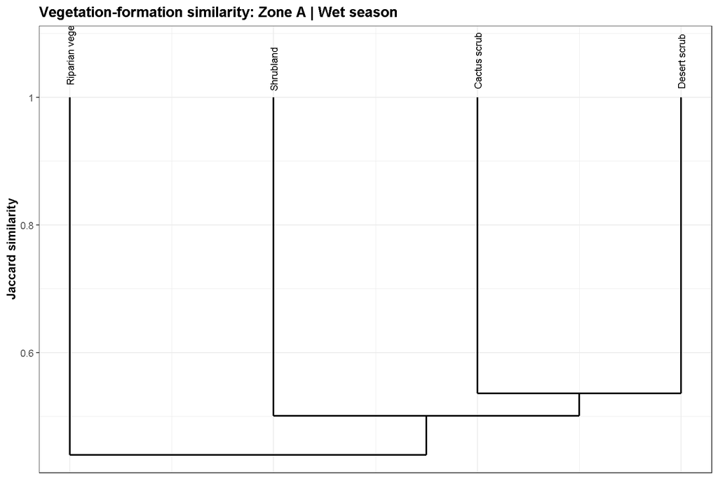

```r
dendrogram_plots[[which(!purrr::map_lgl(dendrogram_plots, is.null))[1]]]
```

# 7 Interpretation notes

Species-accumulation curves are useful for assessing whether the sampling effort is approaching an asymptote. Curves that continue to rise steeply suggest that additional sampling units could reveal more species. Curves that flatten suggest that survey effort has captured a larger proportion of the local flora.

Similarity dendrograms provide a compact way to compare vegetation formations based on community composition. In applied monitoring, this can help identify whether vegetation formations are floristically distinct or whether some formations share similar species-cover profiles.

# 8 Outputs generated by this workflow

When the R Markdown file is run, it generates:

- species-accumulation curves in `outputs/species_area_curves/`
- similarity dendrograms in `outputs/similarity_dendrograms/`
- summary CSV tables in `outputs/tables/`